# Additions to Module0 of Team13

Qifei

2023-10-26

*This Notebook is used for verified the result from teamwork-13 Module 0*

Thanks for Griffin Sheppard, Rohan Anand, Pippa Lin, Irena Wong, and Yibo Liang finished all parts of analyzing the `background-clean.csv` and `interest-clean.csv`.

# Raw-Data Processing

*more to be included* **Note:** It’s important to mention that the original data is split into two table files, and the content within them is not suitable for analysis. As a result, we need to preliminarily organize the data and format character data to be compatible with analyses, such as correlation matrices.

The data processing R script is saved at `~/scripts/Data_Processing.R`, and the steps for data processing are:

1. Import the `background-clean.csv` and `interest-clean.csv` files.
2. Merge the two datasets together using the `merged()` command.
3. Utilize `tidyverse` to encode categorical columns in the dataset: `type`, `lang`, `area`, and `dom.x`.
4. Use `mutate` to transform variables of `character` and `logical` types in the dataset into `int` based on certain rules.
5. Export the results as a CSV for subsequent analysis.

## Encoding Process

In this process, we introduce a function one_hot_encode designed to perform one-hot encoding on a specific column within a dataset, particularly for cases where one row can contain multiple categorical values separated by semicolons.

1. From the `tidyr` package, `rseparate_rows` is used to split multiple categorical values in a single row that are separated by a semicolon (;). Each split value becomes a separate row.
2. Using `mutate` from the `dplyr` package, we introduce a new column `value` and set its value to 1. This step prepares the data for the subsequent one-hot encoding process, where this value column will serve as the indicator (`1` or `0`).
3. The `pivot_wider` function from the `tidyr` package is employed to reshape the data. The unique values from the `starts_with` will be used to create new columns, prefixed with the name of the `starts_with` followed by a dot. The newly introduced `value` column will be the source of values for these new columns. If a certain category is not present for a given row, it will be filled with a 0 (`values_fill = 0`).
4. The `group_by` function from the `dplyr` package is used to group the data by `response.id`. Post grouping, the `summarise` function is utilized to merge the separate rows (originally created by `separate_rows`) back together. The `across` function, paired with `starts_with`, targets the one-hot encoded columns and applies the max function to them. This ensures that if any of the separated rows had the `value` 1 for a category, the summarized row would also have a 1 for that category.

## Transform Data Type

The primary objective here is to convert various categorical representations in the dataset into numerical formats that are suitable for analytical processes. We’ve used a combination of functions and commands from the `dplyr` package to achieve this.

### Character Conversion:

For columns that are of character type, the `mutate` and `across` functions are used to target character columns. Within those columns, the `case_when` function maps specific string values to corresponding integer values.

For example, * Common affirmative values like “yes” or “true” are converted to 1, while negatives like “no” or “false” are converted to 0. * Specific codes like “Adv”, “Int”, “Beg” under the `x.proficiency` are also mapped to 9, 5, and 3 respectively. * Specific columns in updv.num, the system mistakenly recognize options like `6-8`, `3-5` as date format `8-Jun` and `5-Mar`. As a rank of number of class taken `0-2`, `3-5`, `6-8`, and `9+` are mapping to 1, 2, 3, 4 repectively.

This helps standardize the categorical data into a numerical format.

### Logical Conversion:

For columns that are of logical type (TRUE or FALSE), they are straightforward to convert. The `TRUE` value is mapped to 1, and `FALSE` is mapped to 0 using the `as.integer` function.

### Conditional Adjustments:

Based on the value in the `type.both` column, adjustments are made to the `type.lab` and `type.ind` columns. If `type.both` is 1, both `type.lab` and `type.ind` are set to 1.

## Output

You may find the encoded file under `~/data`

# Digging into Data

*following the steps and question mentioned in result*

## Class Counting

Using the processed code, we could easily calculate total number of PSTAT class CS class LING class ECON class each respondent have taken.

- `select(., starts_with("PSTAT"))` selects all columns that start with “PSTAT”.
- `rowSums()` then calculates the row-wise sum across these columns.

Similarly, for the other class types, we use the `starts_with()` function to select the appropriate columns and then compute the sum. The results are stored in new columns `num_PSTAT`, `num_CS`, `num_ECON`, and `num_LING` respectively.

```r
root_dir <- rprojroot::find_rstudio_root_file()
data_dir <- file.path(root_dir, "data")
setwd(data_dir)

merged_data <-read.csv("processed_data.csv")
merged_data <- merged_data %>%
  mutate(
    num_PSTAT = rowSums(select(., starts_with("PSTAT"))),
    num_CS = rowSums(select(., starts_with("CS"))),
    num_ECON = rowSums(select(., starts_with("ECON"))),
    num_LING = rowSums(select(., starts_with("LING"))),
    num_Prog = rowSums(merged_data[, c("PSTAT100", "PSTAT115", "PSTAT126", "PSTAT131", "CS9", "CS16", "CS5A.B", "CS130A.B", "LING110", "LING111")])
  )
```

Drop the course name we could find the basic information for each respondent

```r
basic_info <- merged_data %>%
  select(-c("PSTAT100", "PSTAT120A.B", "PSTAT122", "PSTAT126", "PSTAT131", "PSTAT160A.B", "CS9", "CS16", "PSTAT174", "PSTAT175", "PSTAT127", "PSTAT134", "PSTAT115", "CS5A.B", "ECON145", "CS130A.B", "CS165A.B", "LING110", "LING111"))
```

## Correlation Analysis

To compute the correlation matrix for the `basic_info` dataframe

```r
library(corrplot)
cor_matrix <- cor(basic_info, use = "complete.obs")
```

For Question 1, we focus on the correlation between number of PSTAT classes and other, export the correlation of num_PSTAT with other class.

```r
# Extract the correlation of 'num_PSTAT' with other variables
cor_with_num_PSTAT <- cor_matrix['num_PSTAT', ]
cor_with_num_PSTAT <- cor_with_num_PSTAT[cor_with_num_PSTAT != 1]
sorted_cor <- cor_with_num_PSTAT[order(-abs(cor_with_num_PSTAT))]

# Extract correlations for each category
area_cor <- sorted_cor[str_detect(names(sorted_cor), "^area\\.")]
lang_cor <- sorted_cor[str_detect(names(sorted_cor), "^lang\\.")]
dom_x_cor <- sorted_cor[str_detect(names(sorted_cor), "^dom.x\\.")]
other_cor <- sorted_cor[!names(sorted_cor) %in% c(names(area_cor), names(lang_cor), names(dom_x_cor))]

# Print the results
cat("Top correlated variable within area.* with num_PSTAT is:", names(area_cor)[1:3], "with corresponding correlation:", area_cor[1:3], "\n")
```

```
## Top correlated variable within area.* with num_PSTAT is: area.Spatial.statistics.or.time.series.analysis area.Analysis.or.classification.of.images area.Predictive.modeling..generally with corresponding correlation: 0.4720363 0.4671717 0.2219189
```

```r
cat("Top correlated variable within lang.* with num_PSTAT is:", names(lang_cor)[1:3], "with corresponding correlation:", lang_cor[1:3], "\n")
```

```
## Top correlated variable within lang.* with num_PSTAT is: lang.I.prefer.to.work.in.Python.but.I.am.still.comfortable.with.R. lang.Python lang.R with corresponding correlation: 0.1058843 -0.07584094 0.05436053
```

```r
cat("Top correlated variable within dom.x.* with num_PSTAT is:", names(dom_x_cor)[1:3], "with corresponding correlation:", dom_x_cor[1:3], "\n")
```

```
## Top correlated variable within dom.x.* with num_PSTAT is: dom.x.Demography.and.Linguistic dom.x.Finance dom.x.Social.or.political.science with corresponding correlation: 0.3334565 -0.2734027 0.2374939
```

```r
cat(names(other_cor)[1:10])
```

```
## updv.num num_Prog num_LING num_ECON stat.prof math.prof stat.comf dom.y response.id type.both
```

## Answering Question 1

*Question 1*: Does the number of PSTAT classes taken correlate with the student’s comfort and proficiency in Stats?

```r
sorted_cor['stat.comf'];sorted_cor['stat.prof']
```

```
## stat.comf
## 0.1703432
```

```
## stat.prof
## 0.2100199
```

There is a weak positive correlation between the number of PSTAT classes taken correlate with the student’s comfort and proficiency in statistic.

## Answering Question 2

For Question 2, we focus on the correlation between number of Program-correlated classes and other.

```r
# Extract the correlation of 'num_Prog' with other variables
cor_with_num_Prog <- cor_matrix['num_Prog', ]
cor_with_num_Prog <- cor_with_num_Prog[cor_with_num_Prog != 1]
sorted_cor <- cor_with_num_Prog[order(-abs(cor_with_num_Prog))]

# Extract correlations for each category
area_cor <- sorted_cor[str_detect(names(sorted_cor), "^area\\.")]
lang_cor <- sorted_cor[str_detect(names(sorted_cor), "^lang\\.")]
dom_x_cor <- sorted_cor[str_detect(names(sorted_cor), "^dom.x\\.")]
other_cor <- sorted_cor[!names(sorted_cor) %in% c(names(area_cor), names(lang_cor), names(dom_x_cor))]

# Get the top correlated variable for each category
top_area <- names(area_cor)[1]
top_lang <- names(lang_cor)[1]
top_dom_x <- names(dom_x_cor)[1]
top_other <- names(other_cor)[1]

# Print the results
cat("Top correlated variable within area.* with num_PSTAT is:", names(area_cor)[1:3], "with corresponding correlation:", area_cor[1:3], "\n")
```

```
## Top correlated variable within area.* with num_PSTAT is: area.Analysis.or.classification.of.images area.Deep.learning.and.neural.networks area.Model.deployment.and.software.or.web.integrations with corresponding correlation: 0.3265342 0.2813754 0.2083577
```

```r
cat("Top correlated variable within lang.* with num_PSTAT is:", names(lang_cor)[1:3], "with corresponding correlation:", lang_cor[1:3], "\n")
```

```
## Top correlated variable within lang.* with num_PSTAT is: lang.Python lang.R lang.No.preference with corresponding correlation: 0.291845 -0.1894977 -0.1652686
```

```r
cat("Top correlated variable within dom.x.* with num_PSTAT is:", names(dom_x_cor)[1:3], "with corresponding correlation:", dom_x_cor[1:3], "\n")
```

```
## Top correlated variable within dom.x.* with num_PSTAT is: dom.x.Sports dom.x.AI..LLM..ML.industry.applications dom.x.Machine.Learning with corresponding correlation: -0.3263698 0.2412298 0.2412298
```

```r
cat(names(other_cor)[1:10])
```

```
## num_CS num_PSTAT updv.num dom.y prog.prof prog.comf num_LING math.prof type.ind response.id
```

```r
cat(other_cor[1:10])
```

```
## 0.6082451 0.5449131 0.4357548 0.3216812 0.2859354 0.1926464 0.1590808 0.1415079 -0.1277099 0.1190978
```

```r
sorted_cor['prog.comf'];sorted_cor['prog.prof']
```

```
## prog.comf
## 0.1926464
```

```
## prog.prof
## 0.2859354
```

There is a weak positive correlation between the number of Program-orient classes taken correlate with the student’s comfort and proficiency in programming.

*Additions Beyond Result*: Notice that students taken more program-related class is more comfortable using `Python` as their programming code and less likely to use `R`.

## Answering Question 3

To explore if proficiencies (`stat.prof`, `math.prof`, `prog.prof`) are associated with interests in certain topics (`area.*`), following the systematic approach:

### Descriptive Analysis:

Start by visually examining the distribution of the proficiency columns (`stat.prof`, `math.prof`, `prog.prof`) and the distribution of interests (`area.*`) through histograms or bar plots.

```r
summary(merged_data[c("stat.prof", "math.prof", "prog.prof")])
```

```
##    stat.prof       math.prof       prog.prof
##  Min.   :5.000   Min.   :3.000   Min.   :3.000
##  1st Qu.:5.000   1st Qu.:5.000   1st Qu.:5.000
##  Median :9.000   Median :9.000   Median :5.000
##  Mean   :7.583   Mean   :7.083   Mean   :6.625
##  3rd Qu.:9.000   3rd Qu.:9.000   3rd Qu.:9.000
##  Max.   :9.000   Max.   :9.000   Max.   :9.000
```

```r
summary(select(merged_data, starts_with("area.")))
```

```
##  area.Analysis.or.classification.of.images
##  Min.   :0.000
##  1st Qu.:0.000
##  Median :1.000
##  Mean   :0.625
##  3rd Qu.:1.000
##  Max.   :1.000
##  area.Deep.learning.and.neural.networks
##  Min.   :0.0000
##  1st Qu.:1.0000
##  Median :1.0000
##  Mean   :0.8542
##  3rd Qu.:1.0000
##  Max.   :1.0000
##  area.Spatial.statistics.or.time.series.analysis
##  Min.   :0.0000
##  1st Qu.:0.0000
##  Median :0.0000
##  Mean   :0.4583
##  3rd Qu.:1.0000
##  Max.   :1.0000
##  area.Data.visualization.and.interactive.dashboards
##  Min.   :0.0000
##  1st Qu.:0.0000
##  Median :1.0000
##  Mean   :0.6458
##  3rd Qu.:1.0000
##  Max.   :1.0000
##  area.Predictive.modeling..generally
##  Min.   :0.0000
##  1st Qu.:1.0000
##  Median :1.0000
##  Mean   :0.8542
##  3rd Qu.:1.0000
##  Max.   :1.0000
##  area.Natural.language.processing.and.analysis.of.text.data
##  Min.   :0.00
##  1st Qu.:0.75
##  Median :1.00
##  Mean   :0.75
```

[output cut: 15 more lines]

```
##  Max.   :1.0000
##  area.Statistical.models.and.inference..generally area.Databases
##  Min.   :0.0000                                   Min.   :0.0000
##  1st Qu.:0.0000                                   1st Qu.:0.0000
##  Median :1.0000                                   Median :0.0000
##  Mean   :0.5833                                   Mean   :0.4167
##  3rd Qu.:1.0000                                   3rd Qu.:1.0000
##  Max.   :1.0000                                   Max.   :1.0000
##  area.Algorithms
##  Min.   :0.0000
##  1st Qu.:0.0000
##  Median :1.0000
##  Mean   :0.5625
##  3rd Qu.:1.0000
##  Max.   :1.0000
```

*Histograms for Proficiencies* *The following code is used to solve that cata with 0 frequency will not show in plot*

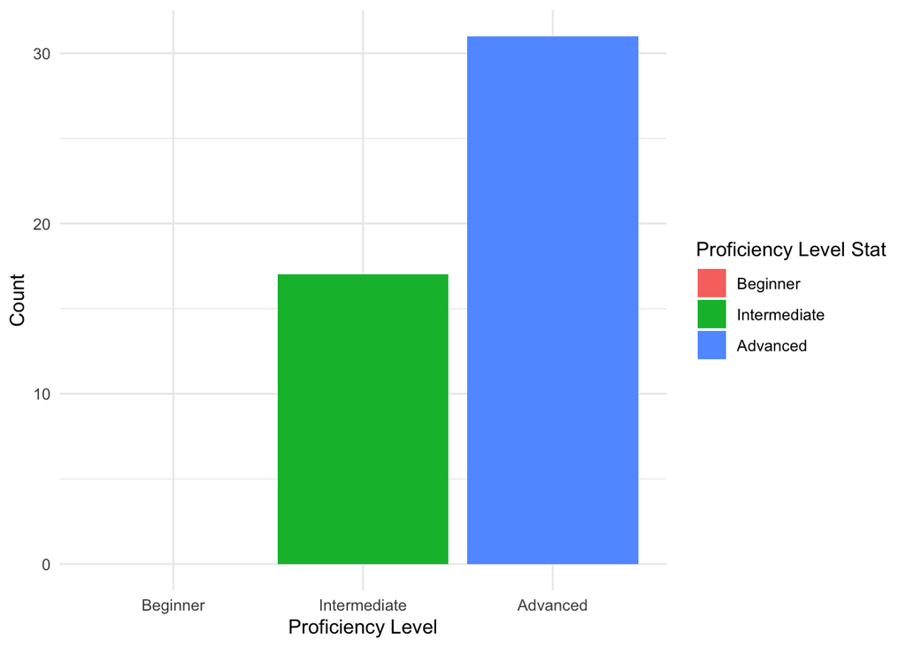

```r
library(ggplot2)

# Convert stat.prof to a factor with specific levels and labels
merged_data$stat.prof_factor <- factor(merged_data$stat.prof,
                                      levels = c(3, 5, 9),
                                      labels = c("Beginner", "Intermediate", "Advanced"))

# Prepare a data frame that ensures all levels have at least one count
plot_data <- as.data.frame(table(merged_data$stat.prof_factor))
plot_data$Var1 <- factor(plot_data$Var1, levels = c("Beginner", "Intermediate", "Advanced"))

# Plot using plot_data
ggplot(plot_data, aes(x = Var1, y = Freq)) +
  geom_bar(stat = "identity", aes(fill = Var1)) +
  labs(x = "Proficiency Level", y = "Count", fill = "Proficiency Level Stat") +
  theme_minimal()
```

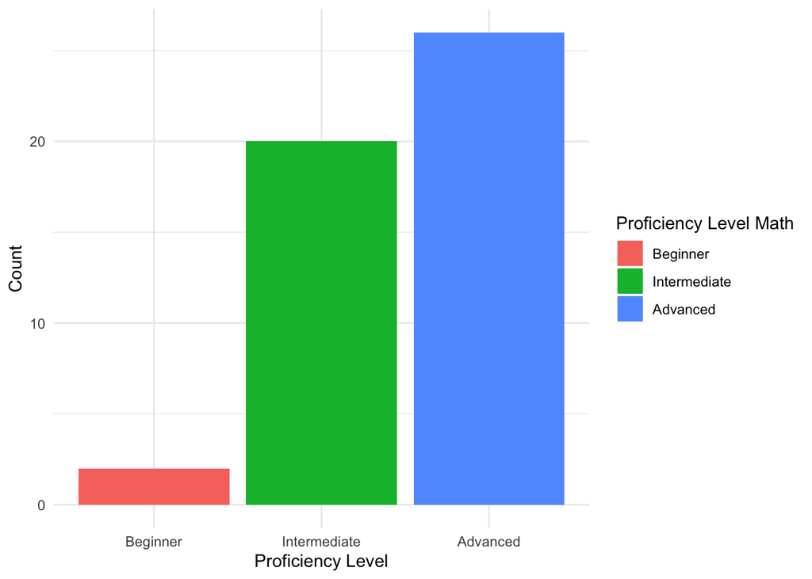

```r
# Convert stat.prof to a factor with specific levels and labels
merged_data$math.prof_factor <- factor(merged_data$math.prof,
                                      levels = c(3, 5, 9),
                                      labels = c("Beginner", "Intermediate", "Advanced"))

# Prepare a data frame that ensures all levels have at least one count
plot_data <- as.data.frame(table(merged_data$math.prof_factor))
plot_data$Var1 <- factor(plot_data$Var1, levels = c("Beginner", "Intermediate", "Advanced"))

# Plot using plot_data
ggplot(plot_data, aes(x = Var1, y = Freq)) +
  geom_bar(stat = "identity", aes(fill = Var1)) +
  labs(x = "Proficiency Level", y = "Count", fill = "Proficiency Level Math") +
  theme_minimal()
```

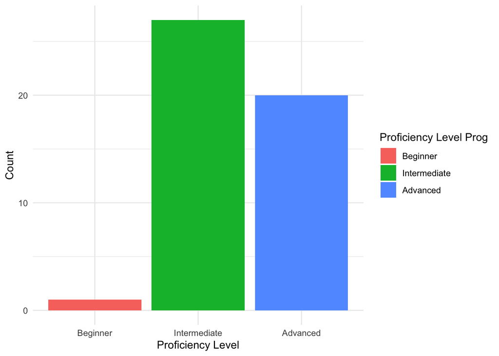

```r
# Convert stat.prof to a factor with specific levels and labels
merged_data$prog.prof_factor <- factor(merged_data$prog.prof,
                                      levels = c(3, 5, 9),
                                      labels = c("Beginner", "Intermediate", "Advanced"))

# Prepare a data frame that ensures all levels have at least one count
plot_data <- as.data.frame(table(merged_data$prog.prof_factor))
plot_data$Var1 <- factor(plot_data$Var1, levels = c("Beginner", "Intermediate", "Advanced"))

# Plot using plot_data
ggplot(plot_data, aes(x = Var1, y = Freq)) +
  geom_bar(stat = "identity", aes(fill = Var1)) +
  labs(x = "Proficiency Level", y = "Count", fill = "Proficiency Level Prog") +
  theme_minimal()
```

*The following code is to achieve same data processing and visualization under the coding merged dataset*

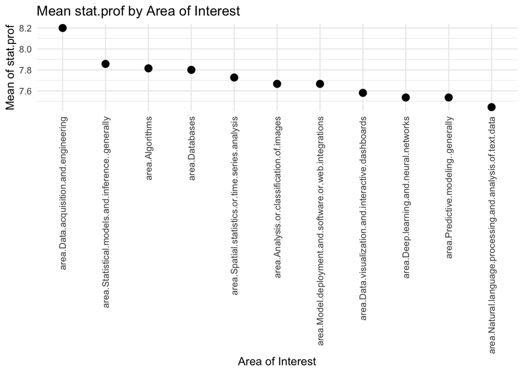

```r
library(tidyverse)
library(tidyverse)

processed_data <- merged_data %>%
  pivot_longer(cols = starts_with("area."),
               names_to = "area",
               values_to = "interest") %>%
  filter(interest == 1) %>%
  group_by(area) %>%
  summarize(mean_stat.prof = mean(stat.prof, na.rm = TRUE)) %>%
  arrange(-mean_stat.prof) %>% # sort in descending order
  mutate(area = factor(area, levels = unique(area)))

# Plot
ggplot(processed_data, aes(x = area, y = mean_stat.prof)) +
  geom_point(size = 3) +
  theme_minimal() +
  theme(axis.text.x = element_text(angle = 90, vjust = 0.5, hjust=1)) + # rotate x-axis text
  labs(x = "Area of Interest", y = "Mean of stat.prof", title = "Mean stat.prof by Area of Interest")
```

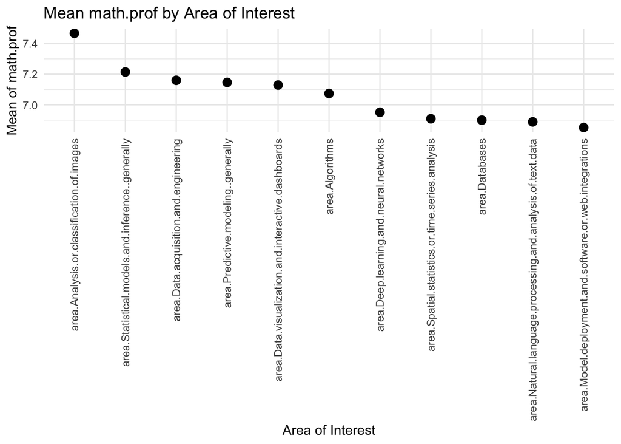

```r
processed_data <- merged_data %>%
  pivot_longer(cols = starts_with("area."),
               names_to = "area",
               values_to = "interest") %>%
  filter(interest == 1) %>%
  group_by(area) %>%
  summarize(mean_math.prof = mean(math.prof, na.rm = TRUE)) %>%
  arrange(-mean_math.prof) %>% # sort in descending order
  mutate(area = factor(area, levels = unique(area)))

# Plot
ggplot(processed_data, aes(x = area, y = mean_math.prof)) +
  geom_point(size = 3) +
  theme_minimal() +
  theme(axis.text.x = element_text(angle = 90, vjust = 0.5, hjust=1)) + # rotate x-axis text
  labs(x = "Area of Interest", y = "Mean of math.prof", title = "Mean math.prof by Area of Interest")
```

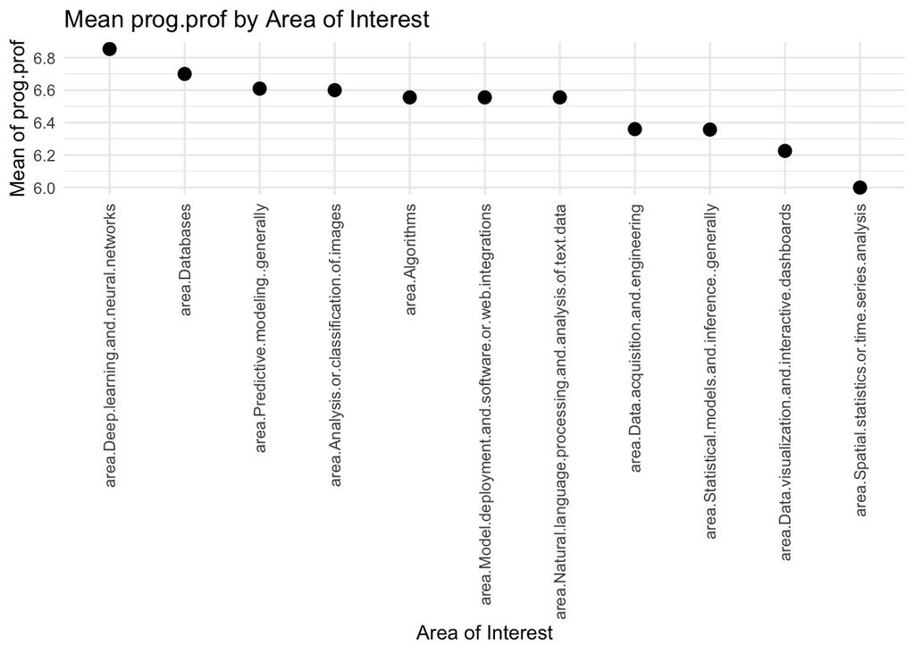

```r
processed_data <- merged_data %>%
  pivot_longer(cols = starts_with("area."),
               names_to = "area",
               values_to = "interest") %>%
  filter(interest == 1) %>%
  group_by(area) %>%
  summarize(mean_prog.prof = mean(prog.prof, na.rm = TRUE)) %>%
  arrange(-mean_prog.prof) %>% # sort in descending order
  mutate(area = factor(area, levels = unique(area)))

# Plot
ggplot(processed_data, aes(x = area, y = mean_prog.prof)) +
  geom_point(size = 3) +
  theme_minimal() +
  theme(axis.text.x = element_text(angle = 90, vjust = 0.5, hjust=1)) + # rotate x-axis text
  labs(x = "Area of Interest", y = "Mean of prog.prof", title = "Mean prog.prof by Area of Interest")
```